# ECON630_Lab2_Qingwen Wang

### Term Distribution Analysis on the address to the United Nations.

```r
# load functions, not run
source("../functions/load_NLP_env.R")

# run load_NLP_env() function.
load_NLP_env("../functions/")
```

```
## [1] "packages loaded:  plyr, dplyr, reshape2, ggplot2, textclean, tm, textstem"
## [1] "functions loaded:  load_NLP_env.R, pre_process_corpus.R"
```

```r
speeches <- read.csv("../datasets/UN_speeches.csv")
```

```r
unique(speeches$country)
```

```
## [1] "CAN" "FRA" "GBR" "ITA" "JPN" "USA" "RUS" "DEU"
```

```r
# filter out speeches addressed by the USA
speeches <- speeches[speeches$country == "USA",]
dim(speeches)
```

```
## [1] 47  3
```

```r
library(countrycode)
# prepare replacement for pre_process_corpus()
countries <- tolower(unique(countryname_dict$country.name.en))
upper_countries <-toupper(countries)
```

```r
# call pre_process function to clean data
text <- pre_process_corpus(speeches, "text", replace_numbers = T,
                           replace_strings = c(countries,upper_countries) ,
                           root_gen = "stem")
```

```r
substr(text[[1]]$content, 1, 200)
```

```
## [1] "on privileg extend warm congratul UNITED STATES deleg elect presid twentyfifth session gener assembli countri peer contribut made work organ father leader leagu nation now session gener assembli ad ne"
```

```r
tokenizer1 <- function(x) {unlist(lapply(ngrams(words(x), 1), paste, collapse = " "), use.names = FALSE)}
tokenizer2 <- function(x) {unlist(lapply(ngrams(words(x), 2), paste, collapse = " "), use.names = FALSE)}
tokenizer3 <- function(x) {unlist(lapply(ngrams(words(x), 3), paste, collapse = " "), use.names = FALSE)}

# set lower bound
lbound <- round(0.015* length(text))

# create DTM
dtm1 <- as.matrix(DocumentTermMatrix(text,
                          control = list(tokenize = tokenizer1,
                                        bounds = list(global = c(lbound, Inf)))))
dtm2 <- as.matrix(DocumentTermMatrix(text,
                          control = list(tokenize = tokenizer2,
                                        bounds = list(global = c(lbound, Inf)))))
dtm3 <- as.matrix(DocumentTermMatrix(text,
                          control = list(tokenize = tokenizer3,
                                        bounds = list(global = c(lbound, Inf)))))

dtm <- cbind(dtm1, dtm2)
dtm <- cbind(dtm, dtm3)
dim(dtm)
```

```
## [1]     47 168244
```

```r
freq_table <- data.frame(term = colnames(dtm), n = colSums(dtm),
                         freq = colSums(dtm)/sum(dtm))

freq_table <- freq_table[order(freq_table$n, decreasing = T),]
head(freq_table)
```

```
##          term    n        freq
## nation nation 1785 0.006122869
## will     will 1258 0.004315165
## world   world 1067 0.003660001
## peopl   peopl  848 0.002908792
## unit     unit  844 0.002895071
## peac     peac  816 0.002799026
```

1. Which terms appear the most frequently in the corpus?

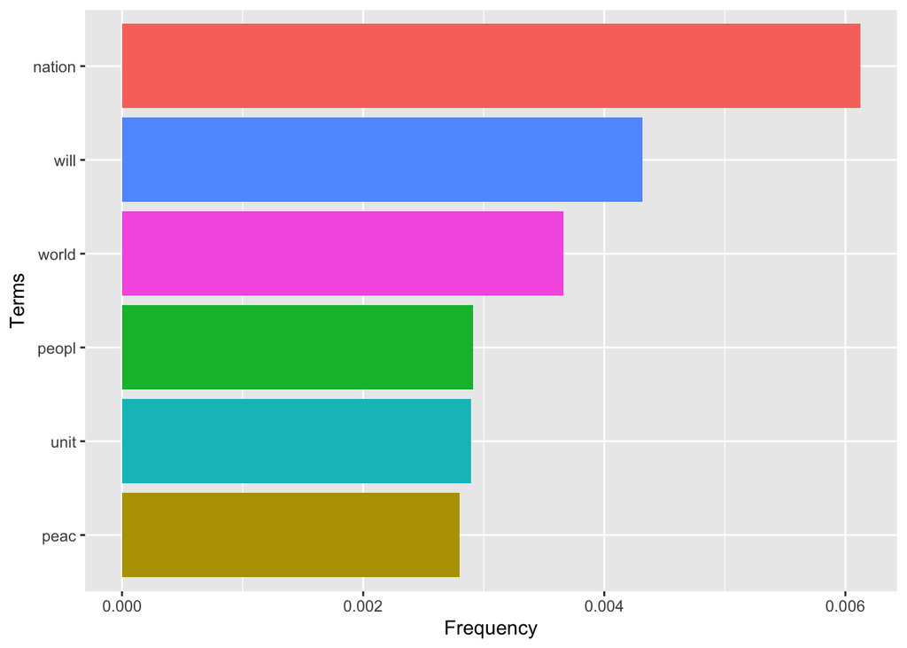

```r
top6 <- freq_table[1:6,]
ggplot(top6, aes(x = reorder(term, freq), y = freq, fill = term)) +
  geom_bar(stat = "identity", show.legend = F) + coord_flip() + xlab("Terms") +  ylab("Frequency")
```

The term “nation” is mentioned mostly in the corpus.

2.Which 10 countries’ names have been mentioned most often and what is their frequency?

```r
countries_mentioned <- freq_table[freq_table$term %in% countries, ]
head(countries_mentioned,10)
```

```
##                        term   n         freq
## united states united states 680 2.332522e-03
## iraq                   iraq 170 5.831304e-04
## israel               israel 101 3.464480e-04
## iran                   iran  89 3.052859e-04
## afghanistan     afghanistan  74 2.538332e-04
## russia               russia  56 1.920900e-04
## china                 china  52 1.783693e-04
## syria                 syria  44 1.509279e-04
## lebanon             lebanon  37 1.269166e-04
## south africa   south africa  29 9.947518e-05
```

```r
# countrycode() is not doenot match term precisely, it will identify any term, which includes country name or adjective of a country name, as a country. So, the mentioned country number counted in this way will be timesed.

freq_table$countryname_modified <- countrycode(freq_table$term, origin = 'country.name', destination = 'cldr.name.en',)

tep <-freq_table[,c("term","n")] %>% group_by(freq_table$countryname_modified) %>% summarise(sum(n))
tep[order(tep$`sum(n)`, decreasing = T),]
```

3.Make a visual of these 10 countries and their frequencies

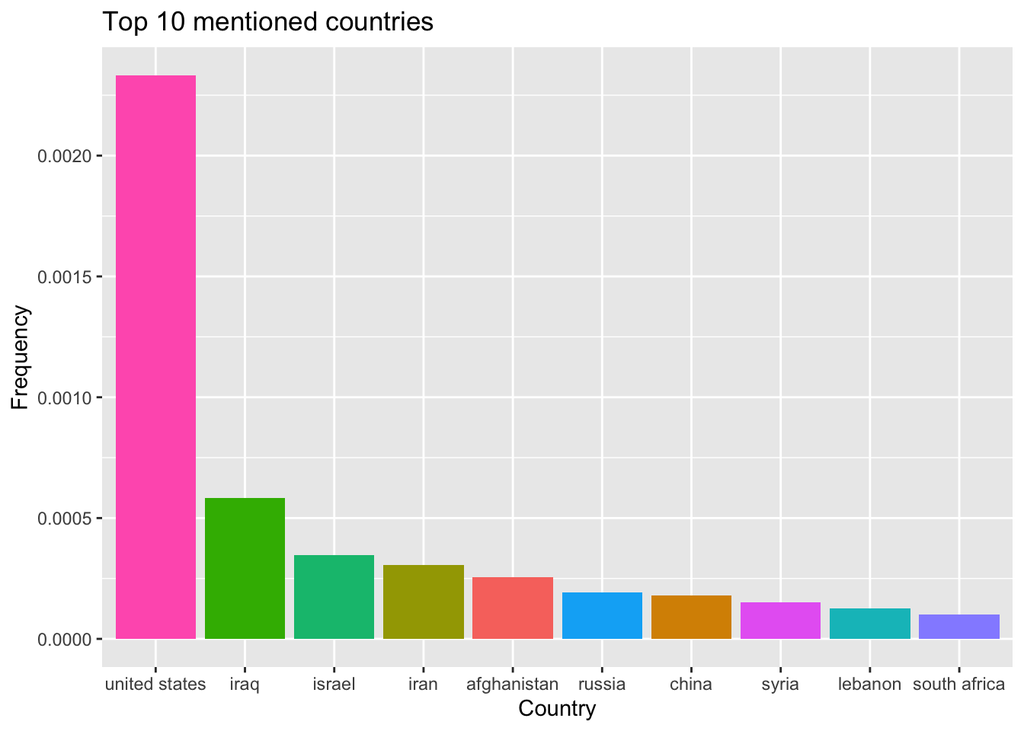

```r
df <- countries_mentioned[1:10,]
ggplot(df, aes(x = reorder(term, -freq), y = freq, fill = term))+ geom_bar(stat = "identity", show.legend = FALSE)+ xlab("Country")+ ylab("Frequency") + ggtitle("Top 10 mentioned countries")
```

4. Of the 5 countries with the highest term count, compare the counts to the mentions of the United States. Show how these terms counts have changed over time.

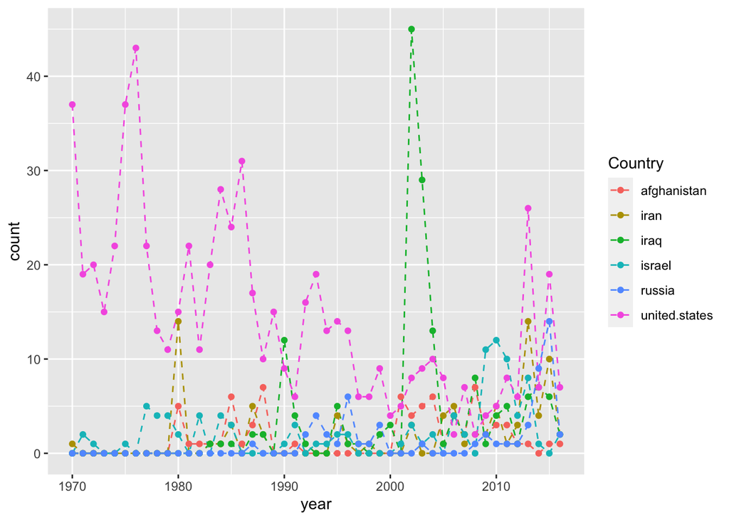

```r
terms <- c(df$term[1:6])
term_count <- dtm[, which(colnames(dtm) %in% terms)]
term_count <- data.frame(year = speeches$year, as.data.frame(term_count))

df2 <- melt(term_count, id.vars = c("year"), variable.name = "term", value.name = "count")
ggplot(df2, aes(x = year, y = count, color = term))+
  geom_line(linetype = 2)+
  geom_point()+
  labs(col ="Country")
```

5.Calculate the TF-IDF values for the DTM. In which year’s address does the term ‘iraq’ provide the most semantic contribution? Evaluate the terms with the highest TF-IDF values in that address. Based on that finding, what do you infer that the speech was about?

```r
# calculate TF-IDF
number_of_docs <- nrow(dtm)
docs_term_appear <- colSums(dtm > 0)
idf <- log(number_of_docs / docs_term_appear)

tf_idf <- t(t(dtm) * idf)
names(tf_idf) <- colnames(dtm)
rownames(tf_idf) <- speeches$year
tf_idf <- data.frame(tf_idf)
```

```r
tf_idf[which.max(tf_idf$iraq),][,c("iraq","abandon")]
```

```
##          iraq abandon
## 2002 23.30744       0
```

In year 2002, “iraq” is most mentioned.

```r
speech_2002 <- tf_idf['2002',]
speech_2002 <- melt(speech_2002)
colnames(speech_2002) <- c("term", "tfidf")
```

```r
# ranking term with high tfidf value
speech_2002[order(speech_2002$tfidf, decreasing = T),][1:15,]
```

```
##                       term    tfidf
## 37855          iraqi.regim 38.52149
## 3560              ninetyon 34.72700
## 35002       hundr.ninetyon 34.72700
## 128653 nine.hundr.ninetyon 34.72700
## 2838                 iraqi 26.98916
## 2837                  iraq 23.30744
## 2564               hussein 19.71083
## 59530       saddam.hussein 19.71083
## 56710           regim.wish 19.25074
## 74372            wish.peac 19.25074
## 116249    iraqi.regim.wish 19.25074
## 141933     regim.wish.peac 19.25074
## 165511      wish.peac.will 19.25074
## 4618                saddam 17.92568
## 41140      longrang.missil 15.40059
```

Based on the term ranking, this speech is probably about the terrorism issues linked to Saddam Hussein in Iraq, as well as the wish of peace is stated.

6. Perform a time series analysis on the terms ‘nuclear,’ ‘terrorist,’ and ‘freedom’ using TF-IDF values. How does the use of these terms change over time? Make a visual and describe your results.

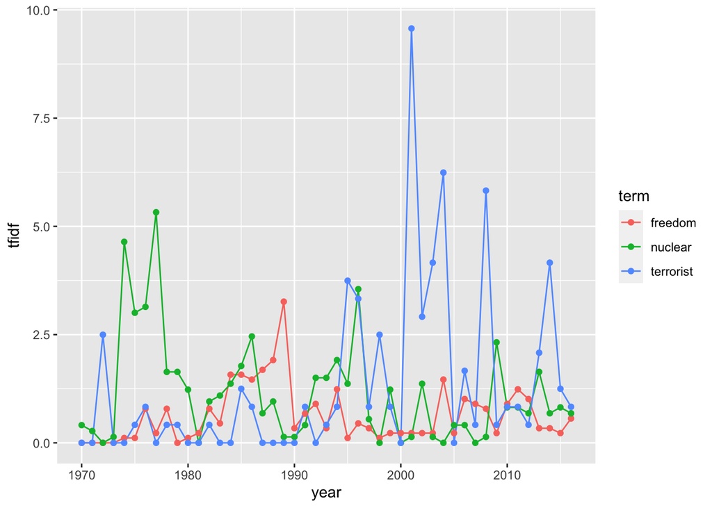

```r
tf_idf_char <- tf_idf[, which(colnames(tf_idf) %in% c('nuclear', 'terrorist','freedom'))]
tf_idf_char <- data.frame(year = speeches$year, as.data.frame(tf_idf_char))

df3 <- melt(tf_idf_char, id.vars = c("year"), variable.name = "term", value.name = "tfidf")
ggplot(df3, aes(x = year, y = tfidf, color = term)) +
  geom_line() + geom_point()
```